# Evaluación Goal 9

Antonio Martínez, Julia Palacios, Arturo Pérez, José Enrique Sánchez

30/3/2021

# 0. LECTURA DE DATOS

```r
goal_9 <- read_delim(file = "data/goal_9.csv", delim = ";")
names(goal_9)[2] = "Target"
names(goal_9)[3] = "Indicator"
names(goal_9)[7] = "AverageValue"
names(goal_9)[5] = "CountryOrArea"
goal_9$AverageValue <- as.numeric(as.character(goal_9$AverageValue))
```

# 1. PLANTEAMIENTO DEL EXPERIMENTO

Vamos a estudiar la correlación entre cuatro medidas que tenemos para evaluar la consecución del OBJETIVO 9: Construir infraestructura resiliente, promover la industrialización inclusiva y sostenible y fomentar la innovación.

Estas cuatro medidas son: . Valor agregado de manufactura per cápita (dólares de los Estados Unidos a precios constantes de 2015) . Flujos oficiales totales de infraestructura, por países receptores (millones de dólares estadounidenses constantes de 2018) . Emisiones de dióxido de carbono por combustión de combustibles (millones de toneladas) . Proporción de población cubierta por al menos una red móvil 2G, 3G o 4G (%)

La última medida ha sido recalculada a partir de 3 medidas: Consistía en un porcentaje de población cubierta con tecnologías 2G, 3G y 4G. Hemos hecho una media con esas tres medidas a fin de obtener cuanta población está cubierta de media con alguna de esas 3 tecnologías.

```r
medida = "Manufacturing value added per capita (constant 2015 United States dollars)"
medida2= "Total official flows for infrastructure, by recipient countries (millions of constant 2018 United States dollars)"
medida3= "Carbon dioxide emissions from fuel combustion (millions of tonnes)"
medidas4 = c("Proportion of population covered by at least a 3G mobile network ()","Proportion of population covered by at least a 2G mobile network ()","Proportion of population covered by at least a 4G mobile network ()")


goal_9_1 <- goal_9 %>%
            filter(Measure == medida,
                   !grepl('Americas|Asia|Africa|Oceania|Europe|ODA|America|developing|Developed|countries|Countries|regions|Channel', CountryOrArea)) %>%
  complete(Year) %>%
  group_by(CountryOrArea,Year) %>%
  arrange(desc(Year,CountryOrArea)) %>%
  select(CountryOrArea,Year,AverageValue)

names(goal_9_1)[1] = "Country"
names(goal_9_1)[3] = "Manufacturing_value_added_per_capita_in_dollars"
```

Medida 2

```r
goal_9_2 <- goal_9 %>%
            filter(Measure == medida2,
                   !grepl('Americas|Asia|Africa|Oceania|Europe|ODA|America|developing|Developed|countries|Countries|regions|Channel', CountryOrArea)) %>%
  complete(Year) %>%
  group_by(CountryOrArea,Year) %>%
  arrange(desc(Year,CountryOrArea)) %>%
  select(CountryOrArea,Year,AverageValue)

names(goal_9_2)[1] = "Country"
names(goal_9_2)[3] = "Total_official_flows_for_infrastructure_millions_of_constant_2018_United_States_dollars"
```

Medida 3

```r
goal_9_3 <- goal_9 %>%
            filter(Measure == medida3,
                   !grepl('Americas|Asia|Africa|Oceania|Europe|ODA|America|developing|Developed|countries|Countries|regions|Channel', CountryOrArea)) %>%
  complete(Year) %>%
  group_by(CountryOrArea,Year) %>%
  arrange(desc(CountryOrArea)) %>%
  select(CountryOrArea,Year,AverageValue)

names(goal_9_3)[1] = "Country"
names(goal_9_3)[3] = "Carbon_dioxide_emissions_from_fuel_combustion_millions_of_tonnes"
```

Medida 4

```r
goal_9_4 <- goal_9 %>%
  select(Target,Indicator,Measure,CountryOrArea,Year,AverageValue,Units) %>%
  filter(Measure %in% c("Proportion of population covered by at least a 3G mobile network ()","Proportion of population covered by at least a 2G mobile network ()","Proportion of population covered by at least a 4G mobile network ()"),
         !grepl('Americas|Asia|Africa|Oceania|Europe|ODA|America|developing|Developed|countries|Countries|regions|Channel', CountryOrArea)) %>%
  complete(Year) %>%
  group_by(CountryOrArea,Year) %>%
  arrange(desc(Year,CountryOrArea)) %>%
  summarize(Mean_population_covered_by_mobile_network=mean(AverageValue))
names(goal_9_4)[1] = "Country"
```

Hacemos una join de las tablas para crear una sola y aplicar una correlación

```r
goal_9_regresion <- goal_9_1 %>%
  left_join(goal_9_2, by = c('Country','Year')) %>%
  left_join(goal_9_3, by = c('Country','Year')) %>%
  left_join(goal_9_4, by = c('Country','Year'))
```

Como podemos observar hay muchos valores incompletos, borraremos las filas que contengan valores incompletos y haremos el estudio con todos los años.

```r
goal_9_regresion_all_years <- goal_9_regresion %>%
  ungroup() %>%
  select(-Year,-Country) %>%
  filter(!is.na(Manufacturing_value_added_per_capita_in_dollars),
         !is.na(Total_official_flows_for_infrastructure_millions_of_constant_2018_United_States_dollars),
         !is.na(Carbon_dioxide_emissions_from_fuel_combustion_millions_of_tonnes),
         !is.na(Mean_population_covered_by_mobile_network))
```

# 2. MATRIZ DE CORRELACIÓN

## 2.1.ÍNDICE DE PEARSON

Para este tipo de correlación es ideal eliminar los outliers, pero nosotros los contenemos en nuestro dataset y eliminarlos supondría perder muchos datos por cada fila. Por lo tanto sabemos que este índice no es el más adecuado para nuestro experimento.

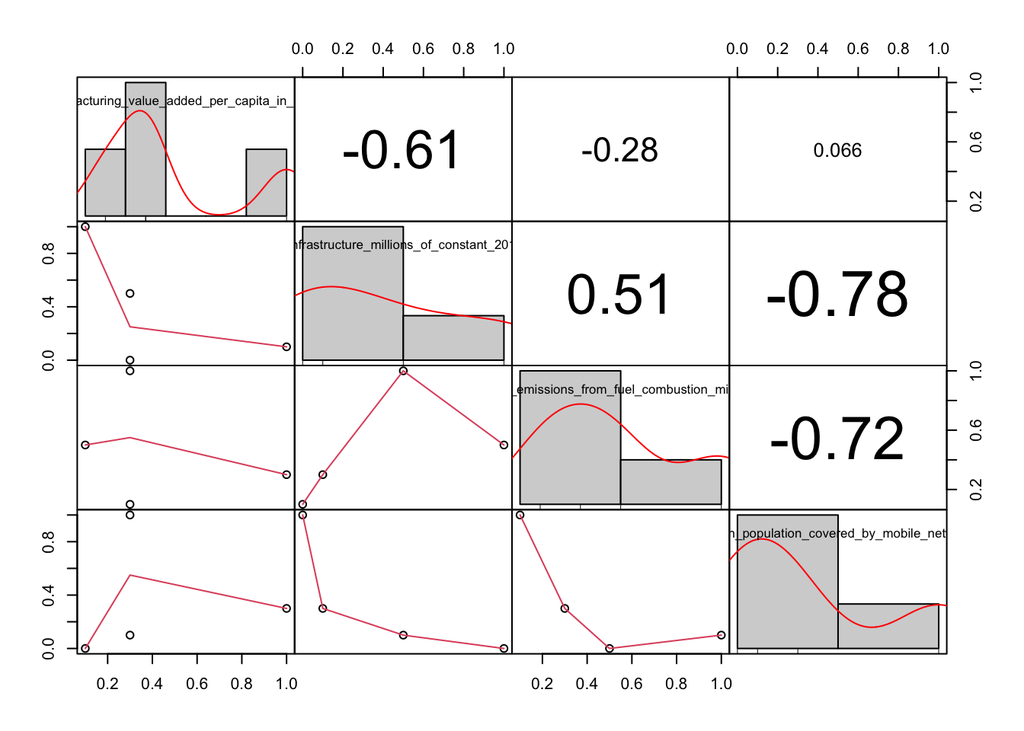

```r
corr <- round(cor(goal_9_regresion_all_years),1)
chart.Correlation(corr, histogram = TRUE, method = "pearson",pch = 20)
```

```r
cor.test(goal_9_regresion_all_years$Mean_population_covered_by_mobile_network,
         goal_9_regresion_all_years$Carbon_dioxide_emissions_from_fuel_combustion_millions_of_tonnes,method="pearson",exact=FALSE)
```

```
##
##  Pearson's product-moment correlation
##
## data:  goal_9_regresion_all_years$Mean_population_covered_by_mobile_network and goal_9_regresion_all_years$Carbon_dioxide_emissions_from_fuel_combustion_millions_of_tonnes
## t = 1.9938, df = 946, p-value = 0.04646
## alternative hypothesis: true correlation is not equal to 0
## 95 percent confidence interval:
##  0.001021143 0.127833181
## sample estimates:
##        cor
## 0.06468832
```

```r
cor.test(goal_9_regresion_all_years$Mean_population_covered_by_mobile_network,
         goal_9_regresion_all_years$Total_official_flows_for_infrastructure_millions_of_constant_2018_United_States_dollars,method="pearson",exact=FALSE)
```

```
##
##  Pearson's product-moment correlation
##
## data:  goal_9_regresion_all_years$Mean_population_covered_by_mobile_network and goal_9_regresion_all_years$Total_official_flows_for_infrastructure_millions_of_constant_2018_United_States_dollars
## t = 0.030976, df = 946, p-value = 0.9753
## alternative hypothesis: true correlation is not equal to 0
## 95 percent confidence interval:
##  -0.06266828  0.06467436
## sample estimates:
##         cor
## 0.001007124
```

```r
cor.test(goal_9_regresion_all_years$Mean_population_covered_by_mobile_network,
         goal_9_regresion_all_years$Manufacturing_value_added_per_capita_in_dollars,method="pearson",exact=FALSE)
```

```
##
##  Pearson's product-moment correlation
##
## data:  goal_9_regresion_all_years$Mean_population_covered_by_mobile_network and goal_9_regresion_all_years$Manufacturing_value_added_per_capita_in_dollars
## t = 10.757, df = 946, p-value < 2.2e-16
## alternative hypothesis: true correlation is not equal to 0
## 95 percent confidence interval:
##  0.2721885 0.3857022
## sample estimates:
##       cor
## 0.3301384
```

## 2.2 ÍNDICE DE SPEARMAN

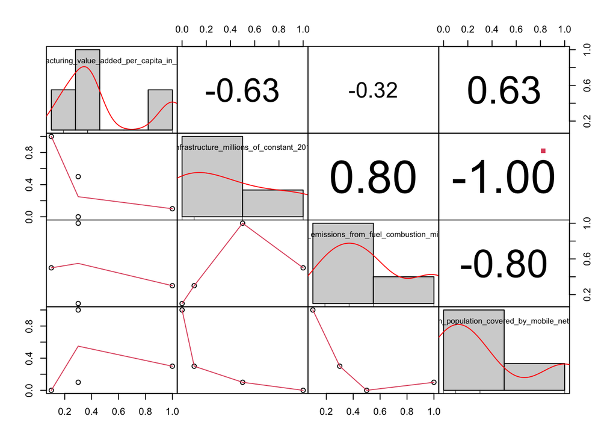

```r
corr <- round(cor(goal_9_regresion_all_years),1)
chart.Correlation(corr, histogram=TRUE, method = c("spearman"), pch="+")
```

```r
cor.test(goal_9_regresion_all_years$Mean_population_covered_by_mobile_network,
         goal_9_regresion_all_years$Carbon_dioxide_emissions_from_fuel_combustion_millions_of_tonnes,method="spearman",exact=FALSE)
```

```
##
##  Spearman's rank correlation rho
##
## data:  goal_9_regresion_all_years$Mean_population_covered_by_mobile_network and goal_9_regresion_all_years$Carbon_dioxide_emissions_from_fuel_combustion_millions_of_tonnes
## S = 119735479, p-value = 1.233e-06
## alternative hypothesis: true rho is not equal to 0
## sample estimates:
##       rho
## 0.1567631
```

```r
cor.test(goal_9_regresion_all_years$Mean_population_covered_by_mobile_network,
         goal_9_regresion_all_years$Total_official_flows_for_infrastructure_millions_of_constant_2018_United_States_dollars,method="spearman",exact=FALSE)
```

```
##
##  Spearman's rank correlation rho
##
## data:  goal_9_regresion_all_years$Mean_population_covered_by_mobile_network and goal_9_regresion_all_years$Total_official_flows_for_infrastructure_millions_of_constant_2018_United_States_dollars
## S = 147518829, p-value = 0.2315
## alternative hypothesis: true rho is not equal to 0
## sample estimates:
##         rho
## -0.03890104
```

```r
cor.test(goal_9_regresion_all_years$Mean_population_covered_by_mobile_network,
         goal_9_regresion_all_years$Manufacturing_value_added_per_capita_in_dollars,method="spearman",exact=FALSE)
```

```
##
##  Spearman's rank correlation rho
##
## data:  goal_9_regresion_all_years$Mean_population_covered_by_mobile_network and goal_9_regresion_all_years$Manufacturing_value_added_per_capita_in_dollars
## S = 82591572, p-value < 2.2e-16
## alternative hypothesis: true rho is not equal to 0
## sample estimates:
##      rho
## 0.418349
```

## 2.4 ESTUDIO DE UN AÑO EN CONCRETO

Probaremos a realizar el mismo estudio con un solo año, para ello haremos un estudio de los valores perdidos, y obtendremos el año con menor porcentaje, de este modo realizaremos la correlación únicamente con dicho año. A fin de obtener un resultado más preciso.

```r
year_filter <- goal_9_regresion %>%
  ungroup() %>%
  distinct(Year)
year_list <- year_filter$Year

for (i in 1:20){
    year <- year_list[i]

    data <- goal_9_regresion %>%
      group_by(Year) %>%
      filter(Year == year) %>%
      ungroup() %>%
      select(-Year,-Country)

    print(year)
    print(colMeans(is.na(data)))
    flush.console()
    if(i==1){
    calc <- data.frame(colMeans(is.na(data))*100)
    }else{
      calc <- calc %>% data.frame(colMeans(is.na(data))*100)
    }
}
```

```
## [1] 2019
##                                         Manufacturing_value_added_per_capita_in_dollars
##                                                                                       0
## Total_official_flows_for_infrastructure_millions_of_constant_2018_United_States_dollars
##                                                                                       1
##                        Carbon_dioxide_emissions_from_fuel_combustion_millions_of_tonnes
##                                                                                       1
##                                               Mean_population_covered_by_mobile_network
##                                                                                       1
## [1] 2018
##                                         Manufacturing_value_added_per_capita_in_dollars
##                                                                               0.0000000
## Total_official_flows_for_infrastructure_millions_of_constant_2018_United_States_dollars
##                                                                               0.3516484
##                        Carbon_dioxide_emissions_from_fuel_combustion_millions_of_tonnes
##                                                                               1.0000000
##                                               Mean_population_covered_by_mobile_network
##                                                                               0.1868132
## [1] 2017
##                                         Manufacturing_value_added_per_capita_in_dollars
##                                                                              0.00000000
## Total_official_flows_for_infrastructure_millions_of_constant_2018_United_States_dollars
##                                                                              0.34426230
##                        Carbon_dioxide_emissions_from_fuel_combustion_millions_of_tonnes
##                                                                              0.34972678
##                                               Mean_population_covered_by_mobile_network
##                                                                              0.05464481
## [1] 2016
##                                         Manufacturing_value_added_per_capita_in_dollars
##                                                                              0.00000000
## Total_official_flows_for_infrastructure_millions_of_constant_2018_United_States_dollars
##                                                                              0.34972678
##                        Carbon_dioxide_emissions_from_fuel_combustion_millions_of_tonnes
##                                                                              0.34426230
##                                               Mean_population_covered_by_mobile_network
##                                                                              0.02185792
## [1] 2015
##                                         Manufacturing_value_added_per_capita_in_dollars
##                                                                              0.00000000
## Total_official_flows_for_infrastructure_millions_of_constant_2018_United_States_dollars
```

[output cut: 125 more lines]

```
## Total_official_flows_for_infrastructure_millions_of_constant_2018_United_States_dollars
##                                                                               0.3500000
##                        Carbon_dioxide_emissions_from_fuel_combustion_millions_of_tonnes
##                                                                               0.3555556
##                                               Mean_population_covered_by_mobile_network
##                                                                               0.5000000
## [1] 2000
##                                         Manufacturing_value_added_per_capita_in_dollars
##                                                                               0.0000000
## Total_official_flows_for_infrastructure_millions_of_constant_2018_United_States_dollars
##                                                                               0.3444444
##                        Carbon_dioxide_emissions_from_fuel_combustion_millions_of_tonnes
##                                                                               0.3555556
##                                               Mean_population_covered_by_mobile_network
##                                                                               0.6111111
```

```r
    colnames(calc) <- year_list
    calct <- data.frame(t(calc))

   calct <- calct %>%
      summarise(meanNAValues = (rowMeans(calct)))
   calct <- cbind(calct,year_list)
   calct %>% arrange(meanNAValues)
```

```
##    meanNAValues year_list
## 1      17.62295      2015
## 2      17.89617      2016
## 3      18.71585      2017
## 4      20.49180      2014
## 5      22.26776      2013
## 6      22.36111      2006
## 7      22.40437      2012
## 8      24.02778      2005
## 9      25.83333      2007
## 10     26.36612      2010
## 11     26.50273      2011
## 12     26.63934      2009
## 13     26.80556      2004
## 14     27.32240      2008
## 15     29.72222      2003
## 16     30.13889      2001
## 17     30.83333      2002
## 18     32.77778      2000
## 19     38.46154      2018
## 20     75.00000      2019
```

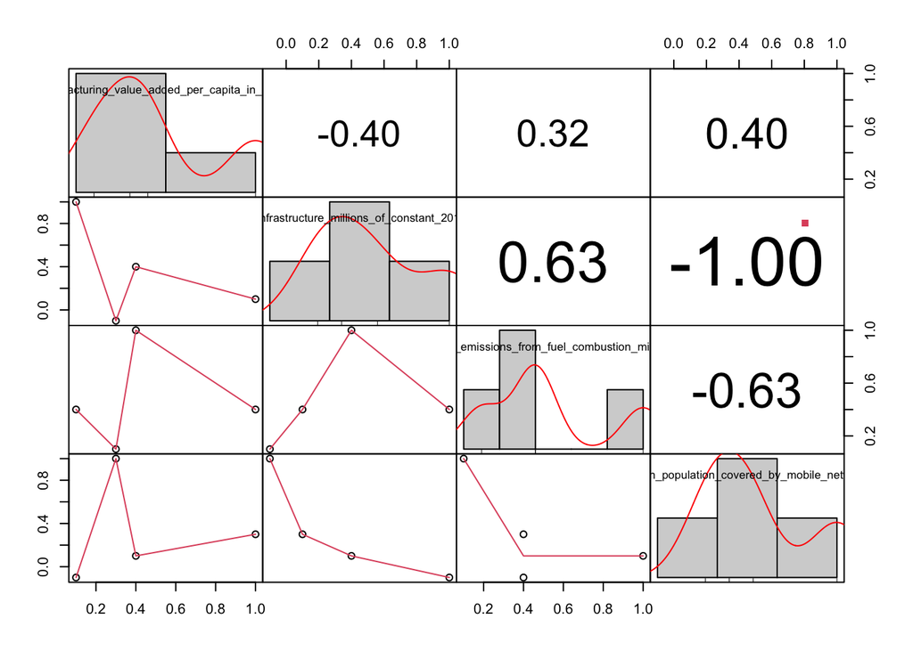

```r
    goal_9_regresion_2015 <- goal_9_regresion %>%
  filter(!is.na(Manufacturing_value_added_per_capita_in_dollars),
         !is.na(Total_official_flows_for_infrastructure_millions_of_constant_2018_United_States_dollars),
         !is.na(Carbon_dioxide_emissions_from_fuel_combustion_millions_of_tonnes),
         !is.na(Mean_population_covered_by_mobile_network),
         Year == 2015) %>%
  ungroup() %>%
  select(-Year,-Country)


corr <- round(cor(goal_9_regresion_2015),1)
chart.Correlation(corr, histogram=TRUE, method = c("spearman"), pch="+")
```

```r
cor.test(goal_9_regresion_2015$Carbon_dioxide_emissions_from_fuel_combustion_millions_of_tonnes,
         goal_9_regresion_2015$Mean_population_covered_by_mobile_network,method="spearman",exact=FALSE)
```

```
##
##  Spearman's rank correlation rho
##
## data:  goal_9_regresion_2015$Carbon_dioxide_emissions_from_fuel_combustion_millions_of_tonnes and goal_9_regresion_2015$Mean_population_covered_by_mobile_network
## S = 57768, p-value = 0.2193
## alternative hypothesis: true rho is not equal to 0
## sample estimates:
##       rho
## 0.1444989
```

Como podemos observar tenemos cerca de un 18% al menos para alguna "medida" de valores perdidos para 2015, pero el año más actual con mejores datos.

## 2.5 MOZAMBIQUE:ESTUDIO DE UN PAÍS EN CONCRETO

Vamos a realizar un estudio para un país en desarrollo en concreto: Mozambique

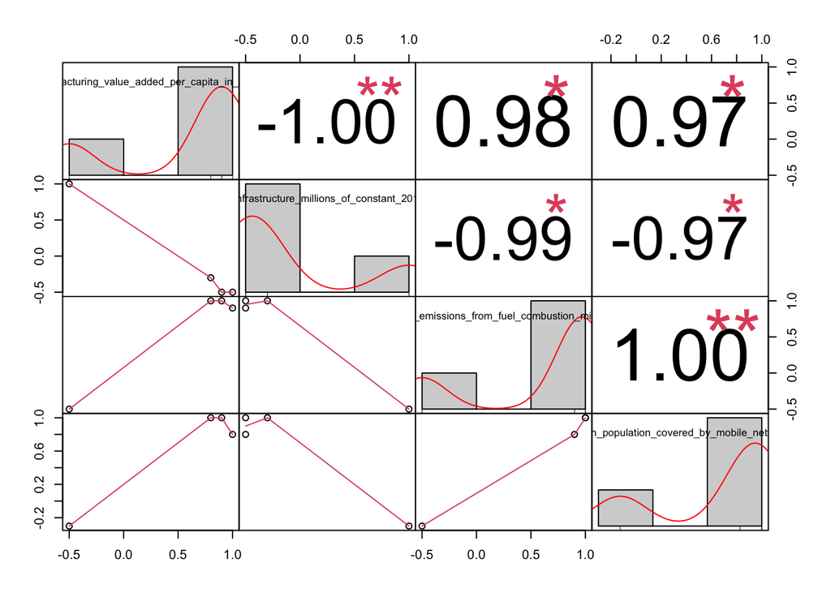

```r
goal_9_regresion_mozambique <- goal_9_regresion %>%
  filter(!is.na(Manufacturing_value_added_per_capita_in_dollars),
         !is.na(Total_official_flows_for_infrastructure_millions_of_constant_2018_United_States_dollars),
         !is.na(Carbon_dioxide_emissions_from_fuel_combustion_millions_of_tonnes),
         !is.na(Mean_population_covered_by_mobile_network),
         Country == "Mozambique") %>%
  ungroup() %>%
  select(-Year,-Country)


corr <- round(cor(goal_9_regresion_mozambique),1)
chart.Correlation(corr, histogram=TRUE, method = c("pearson"), pch="+")
```

```r
cor.test(goal_9_regresion_mozambique$Carbon_dioxide_emissions_from_fuel_combustion_millions_of_tonnes,
         goal_9_regresion_mozambique$Mean_population_covered_by_mobile_network,method="pearson",exact=FALSE)
```

```
##
##  Pearson's product-moment correlation
##
## data:  goal_9_regresion_mozambique$Carbon_dioxide_emissions_from_fuel_combustion_millions_of_tonnes and goal_9_regresion_mozambique$Mean_population_covered_by_mobile_network
## t = 8.8282, df = 4, p-value = 0.0009087
## alternative hypothesis: true correlation is not equal to 0
## 95 percent confidence interval:
##  0.7852642 0.9974004
## sample estimates:
##       cor
## 0.9752857
```

# 3. CONCLUSIONES

Realizando el estudio con un año en particular (2015): Los resultados no son muy buenos, y esto es debido a que en un año en concreto pueden existir países con distintas circunstancias que hagan que nuestra matriz pierda sentido, aún así es parte del experimento.